# 分群(Clustering)

Yao-Jen Kuo

June, 2016

# 摘要

- k-means分群
- 衡量表現與正規化
- 階層式分群

# 分群(Clustering)

- 非監督式學習
- 訓練資料集是沒有答案的, 所以沒有對與錯
- 組內差異小
- 組間差異大
- 差異是以觀測值之間的**距離**作為度量
  - 歐幾里德距離, 曼哈頓距離, …
- 應用 e.g.
  - STP行銷的S(客戶分群)
  - 極端值探勘
  - 預處理(pre-processing)資料
  - …

# 組內距離平方和與組間距離平方和

- 組內距離平方和WSS(Within Cluster Sum of Squares)

$$Min.\,WSS = \sum_{i=1}^{N_C}\sum_{x \in C_i}d(x,\,\bar{x}_{C_i})^2$$

- 組間距離平方和BSS(Between Cluster Sum of Squares)

$$Max.\,BSS = \sum_{i=1}^{N_C}\lvert C_i \rvert \cdot d(\bar{x}_{C_i},\,\bar{x})^2$$

# k-means演算法

- 隨便放 k 個中心點
- 依照各點與 k 個中心點的距離標記分群
- 然後將中心點移到各群的中心
- 重複上兩個步驟一直到中心點的移動已經收斂
- e.g. k = 2

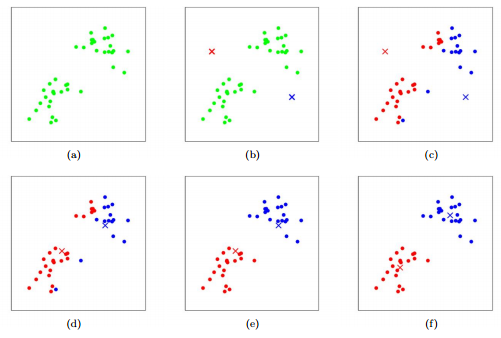

Source: stanford.edu

# k-means演算法 - Hands on

- 使用 `kmeans()` 函數, 輸入 `?kmeans` 查詢這個函數的用法
- `centers` 就是 k 值
- `nstart` 是指重新隨意放 k 個中心點的次數, 一般建議 `nstart >= 10`

```r
iris_km <- iris[, -5]
set.seed(123)
fit_km <- kmeans(iris_km, nstart=20, centers=3)
table(fit_km$cluster, iris[, 5])
```

```
##
##     setosa versicolor virginica
##   1     50          0         0
##   2      0          2        36
##   3      0         48        14
```

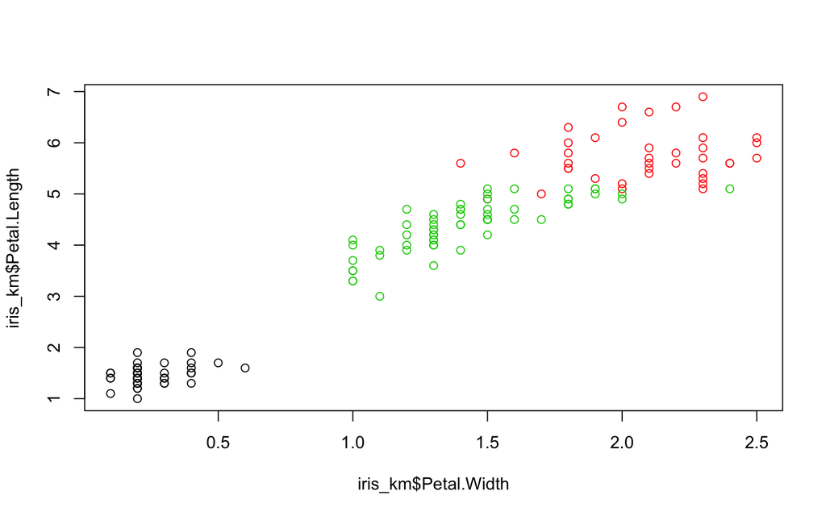

```r
plot(iris_km$Petal.Width, iris_km$Petal.Length, col=fit_km$cluster)
```

# k-means演算法 - Do It Yourself

- 來這裡下載資料集[seedsUCI](https://archive.ics.uci.edu/ml/datasets/seeds)
- 利用 `table` 觀察實際的標籤與分群結果的差別
- 利用 `area` , `compactness` 作圖看看分群結果

```r
seedsUCI <- read.csv("/Users/tkuo/ntu_train/NTUTrainRL3/data/seedsUCI.csv", header = FALSE, col.names = c("area", "perimeter", "compactness", "length", "width", "asymmetry", "grooveLength", "type"))
seeds_km <- seedsUCI[, -8]
fit_km <- kmeans(seeds_km, nstart=20, centers=3)
table(fit_km$cluster, seedsUCI[, 8])
```

```
##
##      1  2  3
##   1 60 10  2
##   2  9  0 68
##   3  1 60  0
```

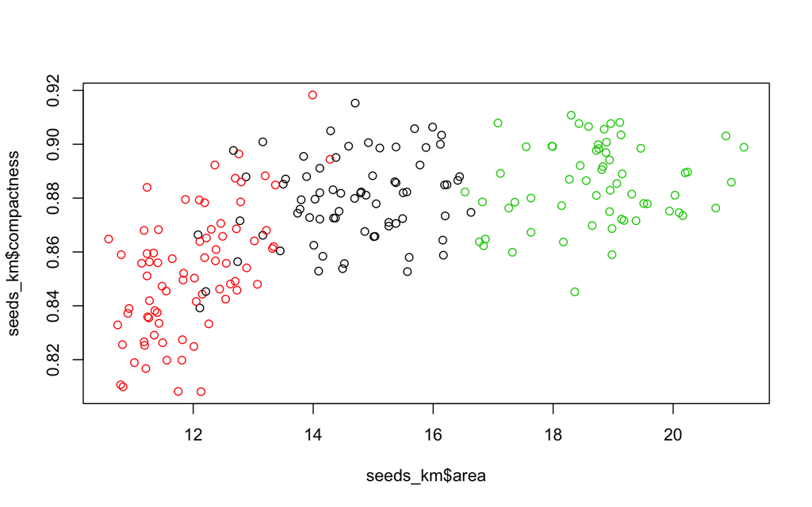

```r
plot(seeds_km$area, seeds_km$compactness, col=fit_km$cluster)
```

# k 要怎麼選擇

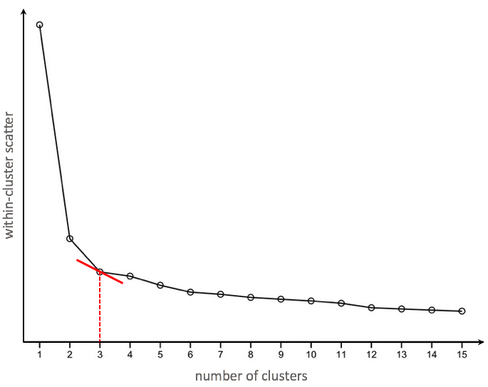

Source: Google Search

# k 要怎麼選擇 - Hands on

- 我們繼續用 `iris` 資料集
- 從 1 群測到 11 群
- 畫陡坡圖

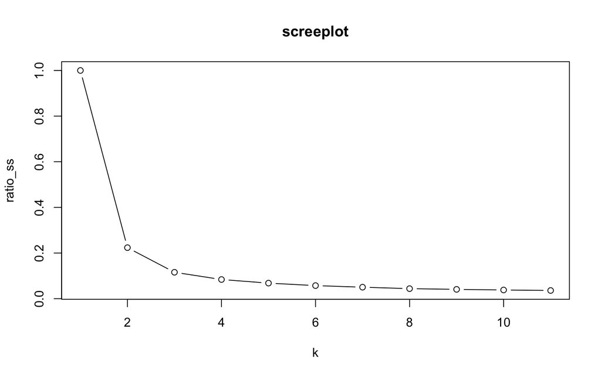

```r
ratio_ss <- rep(NA, times = 11)
for (k in 1:length(ratio_ss)) {
  fit_km <- kmeans(iris_km, centers=k, nstart=20)
  ratio_ss[k] <- fit_km$tot.withinss/fit_km$totss
}
plot(ratio_ss, type="b", xlab="k", main = "screeplot") # "b" as in both
```

# k 要怎麼選擇 - Do It Yourself

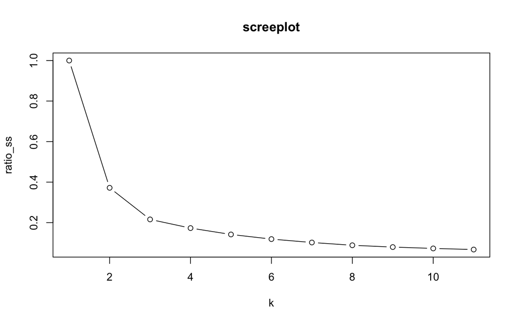

```r
ratio_ss <- rep(NA, times = 11)
for (k in 1:length(ratio_ss)) {
  fit_km <- kmeans(seeds_km, centers=k, nstart=20)
  ratio_ss[k] <- fit_km$tot.withinss/fit_km$totss
}
plot(ratio_ss, type="b", xlab="k", main = "screeplot") # "b" as in both
```

# 唐恩指數Dunn’s Index

- 除了使用 WSS / TSS 這個比例來衡量分群模型的表現, 還可以使用 **唐恩指數Dunn’s Index**
- 唐恩指數利用 `直徑` 來衡量組內差距, 用 `組間距離`來衡量組間差距
- 直徑

$${Dia}_i = \max_{x,y \in C_i}\,d(x,y)$$

- 組間距離

$$\sigma (C_i,\,C_j) = \min_{x \in C_i, y \in C_j}d(x, \, y)$$

- 唐恩指數Dunn’s Index

$$\frac{\min_{1 \le i \le j \le k} \sigma(C_i, \, C_j)}{\max_{1 \le m \le k}{Dia}_m}$$

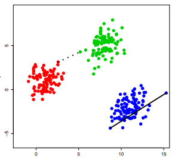

Source: DataCamp

# 唐恩指數Dunn’s Index - Hands on

- 唐恩指數愈高, 分群的效果愈好
- 使用 `clValid` 套件中的 `dunn()` 函數

```r
library(clValid)
iris_km <- iris[, -5]
set.seed(123)
fit_km <- kmeans(iris_km, nstart=20, centers=3)
dunn(clusters = fit_km$cluster, Data = iris_km)
```

```
## [1] 0.09880739
```

# 唐恩指數Dunn’s Index - Do It Yourself

- 來這裡下載資料集[seedsUCI](https://archive.ics.uci.edu/ml/datasets/seeds)
- 用 `seedsUCI` 練習算出唐恩指數(`nstart` = 20, `centers` = 3)

```r
set.seed(123)
fit_km <- kmeans(seeds_km, nstart=20, centers=3)
dunn(clusters = fit_km$cluster, Data = seeds_km)
```

```
## [1] 0.0855068
```

# 正規化 - Hands on

- 還記得你在 k-NN 分類時碰到過的單位問題嗎?
- 只要利用觀測值的 `距離遠近` 都要處理
- 先前我們的正規化是自己用Min Max方法計算
- 現在使用 `scale()` 來做這件事吧!
- `scale()` 標準化為 `z-score` 方法

```r
mtcars_km <- mtcars
fit_km <- kmeans(mtcars_km, centers = 5, nstart = 10)
mtcars_km_norm <- data.frame(scale(mtcars))
fit_km_norm <- kmeans(mtcars_km_norm, centers = 5, nstart = 10)
# 比較兩個唐恩指數
dunn(clusters = fit_km$cluster, Data = mtcars_km)
```

```
## [1] 0.1743059
```

```r
dunn(clusters = fit_km_norm$cluster, Data = mtcars_km_norm)
```

```
## [1] 0.6849157
```

# 階層式分群

- k-means分群一定要指定參數 `k` , 意即你必須一開始心中對於群數就要有主見
- 階層式分群則是從每一個觀測值自成一類開始分群

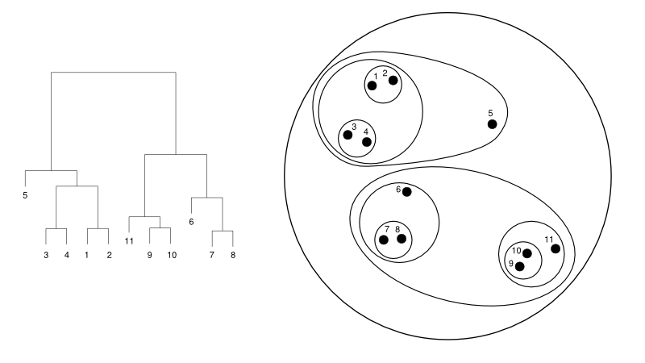

Source: Johns Hopkins University

- 衡量群集之間的距離時有**3**種計算方式
  - 單一連結: 僅衡量群集間的最短距離
  - 完整連結: 僅衡量群集間的最大距離
  - 平均連結: 衡量群集間的平均距離

# 階層式分群 - Hands on

- 讓我們用 `crime_data` 資料集來練習一下
- 在[edureka!](http://www.edureka.co/blog/implementing-kmeans-clustering-on-the-crime-dataset/)下載資料集
- 首先要用 `dist()` 函數把所有觀測值的距離矩陣算出來
- 然後使用 `hclust()` 函數建模

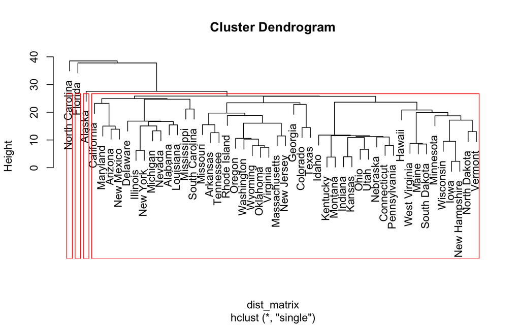

```r
crime_data <- read.csv("/Users/tkuo/ntu_train/NTUTrainRL3/data/crime_data.csv")
crime_data_num <- crime_data[, c(-1:-2)]
row.names(crime_data_num) <- crime_data[, 1]
dist_matrix <- dist(crime_data_num)
crime_single <- hclust(dist_matrix, method = "single")
crime_single_hclust <- cutree(crime_single, k = 4)
plot(crime_single)
rect.hclust(tree=crime_single, k=4)
```

```r
dunn(clusters = crime_single_hclust, Data = crime_data_num)
```

```
## [1] 0.1071949
```

# 階層式分群 - Do It Yourself

```r
crime_complete <- hclust(dist_matrix, method = "complete")
crime_complete_hclust <- cutree(crime_complete, k = 4)
crime_km_norm <- data.frame(scale(crime_data_num))
fit_km_norm <- kmeans(crime_km_norm, centers = 4, nstart = 10)
dunn(clusters = crime_single_hclust, Data = crime_data_num)
```

```
## [1] 0.1071949
```

```r
dunn(clusters = fit_km_norm$cluster, Data = crime_km_norm)
```

```
## [1] 0.1604403
```